# Práctica de Programación con R

Rocio Conislla

29/6/2021

# **EJERCICIOS**.

### **Parte 1**.

1. Piden calcular los valores númericos aproximados de:
1. $$\frac{0.3*0.15}{0.3*0.15+0.2*0.8+0.5*0.12}$$
   Solución:

```r
(0.3*0.15)/(0.3*0.15+0.2*0.8+0.5*0.12)
```

```
## [1] 0.1698113
```

2. $$\frac{5^6}{6!}*e^{-5}$$
   Solución:

```r
((5^6)/factorial(6))*exp(-5)
```

```
## [1] 0.1462228
```

3. $$\begin{pmatrix}
   20 \\ 7
   \end{pmatrix}
   *0.4^7*0.6^{13}$$
   Solución:

```r
choose(20,7)*(0.4^7)*(0.6^13)
```

```
## [1] 0.1658823
```

2. Piden realizar las siguientes sumas:
1. $$1+2+3+\ldots+1000$$
   Solución:

```r
sum(1:1000)
```

```
## [1] 500500
```

2. $$1+2+4+8+16+\ldots+1024$$
   Solución:

```r
sum(2^(0:10))
```

```
## [1] 2047
```

3. El vector **grupo** representa al grupo al que pertenece una serie de alumnos piden:
1. ¿Cuántos elementos tiene?

Solución: -Primero cargamos la data

```r
data <- load("datos.RData")
```

-Para visualizar la cantidad de elementos que tiene usamos la función **length**

```r
length(grupo)
```

```
## [1] 192
```

2. ¿En qué posiciones del vector está la letra “A”? -Para visualizar las posiciones en las que se encuentra la letra **A** usamos **which**

```r
which(grupo == "A")
```

```
##  [1]   2   8  17  21  28  84 101 108 111 115 123 136 190 192
```

4. El vector **nota** representa la nota de un examen de los alumnos que están en los grupos del vector **grupo**. Piden:
1. ¿Cuánto suman todas las notas?

Solución:

```r
sum(nota)
```

```
## [1] 962
```

2. ¿Cuál es la media aritmética de todas las notas?

Solución:

```r
mean(nota)
```

```
## [1] 5.010417
```

3. ¿En qué posiciones están las notas mayores de 7.0?

Solución:

```r
which(nota >= 7.0)
```

```
## [1]  73  81 103 120 151
```

4. Visualiza las notas ordenadas de mayor a menor

Solución:

```r
sort(nota, decreasing = T)
```

```
##   [1] 7.7 7.5 7.4 7.2 7.0 6.9 6.9 6.8 6.8 6.8 6.8 6.8 6.6 6.5 6.4 6.4 6.4 6.4
##  [19] 6.3 6.2 6.2 6.2 6.2 6.2 6.2 6.1 6.1 6.1 6.1 6.0 6.0 6.0 6.0 6.0 6.0 5.9
##  [37] 5.9 5.9 5.9 5.9 5.9 5.9 5.9 5.9 5.8 5.8 5.8 5.8 5.8 5.7 5.7 5.7 5.7 5.7
##  [55] 5.6 5.6 5.6 5.6 5.6 5.6 5.5 5.5 5.5 5.5 5.5 5.5 5.5 5.5 5.5 5.5 5.5 5.5
##  [73] 5.5 5.4 5.4 5.4 5.4 5.4 5.4 5.4 5.4 5.3 5.3 5.3 5.3 5.2 5.2 5.2 5.2 5.2
##  [91] 5.2 5.2 5.1 5.0 5.0 5.0 5.0 5.0 5.0 5.0 5.0 5.0 4.9 4.9 4.9 4.9 4.9 4.9
## [109] 4.8 4.8 4.8 4.8 4.8 4.8 4.7 4.7 4.7 4.7 4.7 4.7 4.7 4.7 4.7 4.7 4.6 4.6
## [127] 4.6 4.6 4.5 4.5 4.5 4.5 4.5 4.5 4.4 4.4 4.4 4.4 4.4 4.4 4.4 4.3 4.3 4.3
## [145] 4.2 4.2 4.2 4.2 4.2 4.2 4.2 4.2 4.1 4.1 4.1 4.1 4.1 4.0 4.0 4.0 4.0 4.0
## [163] 4.0 3.9 3.9 3.8 3.8 3.8 3.7 3.7 3.7 3.7 3.6 3.6 3.6 3.5 3.4 3.4 3.4 3.4
## [181] 3.2 3.2 3.2 3.1 3.0 2.9 2.9 2.9 2.7 2.6 2.5 1.7
```

5. ¿En qué posición está la nota máxima?

Solución:

```r
which(nota == max(nota))
```

```
## [1] 120
```

5. A partir de los vectores **grupo** y **nota** definidos. Piden:
1. Suma de las notas de los 10 primeros alumnos del vector

Solución

```r
sum(nota[1:10])
```

```
## [1] 51.8
```

2. ¿Cuántos alumnos hay en el grupo **C**?

Solución

```r
length(grupo[grupo=="C"])
```

```
## [1] 39
```

3. ¿Cuántos alumnos han aprobado?

Solución:

```r
length(nota[nota>=5])
```

```
## [1] 102
```

4. ¿Cuántos alumnos del grupo **B** han aprobado?

Solución:

```r
length(nota[grupo == "B" & nota >= 5])
```

```
## [1] 12
```

5. ¿Qué porcentaje de alumnos del grupo **C** han aprobado?

Solución:

```r
(length(nota[grupo == "C" & nota >= 5])/length(nota[grupo == "C"]))*100
```

```
## [1] 58.97436
```

6. ¿De qué grupos son la máxima y mínima notas de toda la muestra?

Solución:

```r
#La nota máxima es del grupo:
grupo[nota == max(nota)]
```

```
## [1] "E"
```

```r
#La nota mínima es del grupo:
grupo[nota == min(nota)]
```

```
## [1] "B"
```

7. Nota media de los alumnos del grupo **A** y **B**, juntos, considerando solo a los que han aprobado.

Solución:

```r
mean(c(nota[grupo == "A" & nota >= 5],nota[grupo == "B" & nota >= 5]))
```

```
## [1] 5.825
```

6. Piden calcular el percentil 66 de las notas de todos los alumnos, y también de los alumnos del grupo **C**.

Solución:

```r
quantile(nota, probs = 0.66)
```

```
## 66%
## 5.5
```

```r
quantile(nota[grupo=="C"], probs = 0.66)
```

```
##   66%
## 5.808
```

7. Un alumno tiene una nota de 4.9 ¿Qué procentaje del total de alumnos, tiene una nota menor o igual que la suya?¿Y qué porcentaje tiene una nota mayor o igual que la suya?

Solución:

```r
#Porcentaje de alumnos que tiene una nota menor o igual a 4.9
((length(nota[nota <= 4.9]))/(length(nota)))*100
```

```
## [1] 46.875
```

```r
#Porcentaje de alumnos que tiene una nota mayor o igual a 4.9
((length(nota[nota >= 4.9]))/(length(nota)))*100
```

```
## [1] 56.25
```

8. Realizar un gráfico de diagramas de caja de notas de cada grupo, para poder comparar el nivel de cada uno de ellos.

Solución:

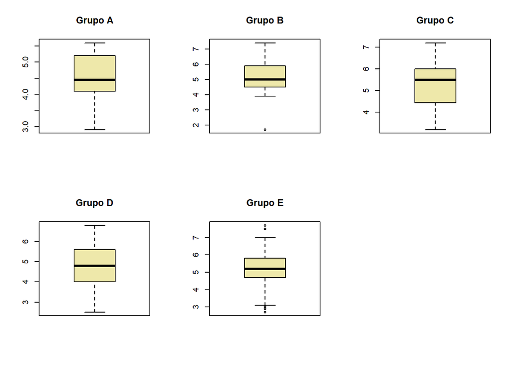

```r
par(mfrow = c(2,3))
boxplot(nota[grupo == "A"], main = "Grupo A", col = "palegoldenrod")
boxplot(nota[grupo == "B"], main = "Grupo B", col = "palegoldenrod")
boxplot(nota[grupo == "C"], main = "Grupo C", col = "palegoldenrod")
boxplot(nota[grupo == "D"], main = "Grupo D", col = "palegoldenrod")
boxplot(nota[grupo == "E"], main = "Grupo E", col = "palegoldenrod")
```

9. Si la variable **conc** recoge la concentración de plomo (en ppm) en el aire en cierta zona durante un día completo, piden:
1. ¿Cuál ha sido la concentración máxima?

Solución:

```r
max(conc)
```

```
## [1] 47.34
```

2. ¿En cuántos de los muestreos se ha superado la concentración de 40.0 ppm?

Solución:

```r
length(conc[conc > 40])
```

```
## [1] 61
```

3. ¿Cuál ha sido la concentración media del día?

Solución:

```r
mean(conc)
```

```
## [1] 24.07229
```

4. ¿Cuales fueron las 10 mediciones más bajas del día?

Solución:

```r
sort(conc)[1:10]
```

```
##  [1] 0.93 1.07 1.77 2.03 2.58 2.73 2.75 2.88 2.88 2.91
```

5. Si la primera medida fue a las 00:00. ¿A qué hora del día se alcanzó la concentración máxima?

Solución:

```r
# Creaamos una secuencia de datos de fecha con inicio en la hora pedida:
date1 <- seq(
  as.POSIXct("2021-01-01 00:00"),
  length.out = length(conc),
  by = "5 min"
)

#Creamos un data frame con los datos de concentracion de plomo y las fechas
df03 <- data.frame(conc, date1)

#Consultamos cual es el valor maximo de concentracion y a su vez nos trae el dato de la hora en que fue tomada
df03[conc == max(conc),]
```

```
##      conc               date1
## 142 47.34 2021-01-01 11:45:00
```

### **Parte 2**.

Solución:

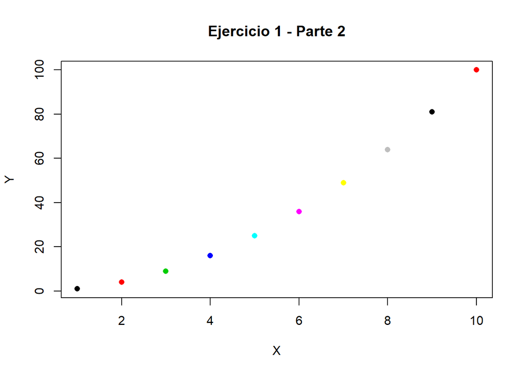

```r
plot(matrix(c(1:10,(1:10)^2), nrow = 10), xlab = "X", ylab = "Y",
     main = "Ejercicio 1 - Parte 2",pch = 16, col=1:10)
```

2. Piden ingresar la matriz A en Rstudio:

$$A=
\begin{pmatrix}
1&2&3\\2&4&6\\3&6&9\\4&8&12
\end{pmatrix}$$
Solución:

```r
matrix(c(1,2,3,2,4,6,3,6,9,4,8,12), nrow = 4, byrow = T)
```

```
##      [,1] [,2] [,3]
## [1,]    1    2    3
## [2,]    2    4    6
## [3,]    3    6    9
## [4,]    4    8   12
```

3. Piden ingresar la matriz identidad de tamaño 3:
   $$I=
   \begin{pmatrix}
   1&0&0\\0&1&0\\0&0&1
   \end{pmatrix}$$
   Solución:

```r
diag(x = 1,nrow = 3)
```

```
##      [,1] [,2] [,3]
## [1,]    1    0    0
## [2,]    0    1    0
## [3,]    0    0    1
```

4. Piden crear una función que cree una matriz nula ingresando las dimensiones.

Solución:

```r
matrix_null <- function(val1,val2){
  resultado <- matrix(0, nrow = val1, ncol = val2)
  return(resultado)
}
matrix_null(4,5)
```

```
##      [,1] [,2] [,3] [,4] [,5]
## [1,]    0    0    0    0    0
## [2,]    0    0    0    0    0
## [3,]    0    0    0    0    0
## [4,]    0    0    0    0    0
```

5. Piden modificar la matriz **diag(4)**, para que se parezca a la matriz **B**:
   $$B=
   \begin{pmatrix}
   0&0&0&0\\0&2&0&0\\0&0&3&0\\0&0&0&4
   \end{pmatrix}$$
   Solución:

```r
diag(x = c(0,2,3,4),nrow = 4)
```

```
##      [,1] [,2] [,3] [,4]
## [1,]    0    0    0    0
## [2,]    0    2    0    0
## [3,]    0    0    3    0
## [4,]    0    0    0    4
```

6. Piden obtener la matriz transpuesta de A(ejercicio2):

Solución:

```r
A1 <- matrix(c(1,2,3,2,4,6,3,6,9,4,8,12), nrow = 4, byrow = T)
t(A1)
```

```
##      [,1] [,2] [,3] [,4]
## [1,]    1    2    3    4
## [2,]    2    4    6    8
## [3,]    3    6    9   12
```

7. Piden realizar las siguientes operaciones:
1. $$A+B$$
2. $$A-B$$
   Los ejercicios 7a, y 7b no se pueden operar debido a que tienen dimensiones diferentes.
3. $$3B$$
   Solución:

```r
B1 <- diag(x = c(0,2,3,4),nrow = 4)
3*B1
```

```
##      [,1] [,2] [,3] [,4]
## [1,]    0    0    0    0
## [2,]    0    6    0    0
## [3,]    0    0    9    0
## [4,]    0    0    0   12
```

4. $$BA$$
   Solución:

```r
B1%*%A1
```

```
##      [,1] [,2] [,3]
## [1,]    0    0    0
## [2,]    4    8   12
## [3,]    9   18   27
## [4,]   16   32   48
```

8. Piden crear una función para calcular $P^6$.
   $$P=
   \begin{pmatrix}
   1&2&3\\-2&4&-2\\1&0&1
   \end{pmatrix}$$
   Solución:

```r
p = matrix(c(1,2,3,-2,4,-2,1,0,1), nrow = 3, byrow = T)

f2 <- function(x,k){
  r <- diag(dim(x)[2])
  for(i in 1:k){
    r <- r%*%x
  }
  r
}
f2(p,6)
```

```
##       [,1]  [,2]  [,3]
## [1,] -1792    24 -2824
## [2,]  -464 -2416 -1344
## [3,]  -648   440  -912
```

9. Piden resolver el sistema de ecuaciones.
   $$3x-y+z=-1\\
   9x-2y+z=-9\\
   3x+y-2z=-9$$
   Solución:

```r
A2 <- rbind(c(3, -1, 1),
           c(9, -2, 1),
           c(3, 1, -2))
B2 <- c(-1, -9, -9)
solve(A2, B2)
```

```
## [1] -1  2  4
```

10. Utilizando la ayuda de R, piden investigar para qué sirven las funciones **eigen()** y **det()**.

Solución:

```r
#?eigen()
#?det()
```

11. Considerando las matrices.
    $$B=
    \begin{pmatrix}
    1&2&3&4&5\\2&4&6&8&10\\3&6&9&12&15\\4&8&12&16&20\\5&10&15&20&25\\6&12&18&24&30\\7&14&21&28&35\\8&16&24&32&40\\9&18&27&36&45\\10&20&30&40&50
    \end{pmatrix}$$
    $$A=
    \begin{pmatrix}
    0&1&0&1&0\\1&0&1&0&1\\0&1&0&1&0\\0&1&0&0&1\\1&0&1&1&0
    \end{pmatrix}$$
    Piden calcular:
    $$A*B-AB^t$$
    Solución:

```r
B <- matrix(c(1:10, seq(2, 20, by = 2), seq(3, 30, by = 3), seq(4, 40, by = 4),
               seq(5, 50, by = 5)), nrow = 10)
A <- matrix(c(rep(c(0,1),7), rep(c(0,0,1),2),1,0,1,1,0), nrow = 5, byrow = T)

#Error en las dimensiones: (B)%*%(A)-(A)%*%t(B)
```

12. Considere:
    $$\beta = (X^t*X)^{-1}*X^t*Y$$
    Piden determinar la matriz $\beta$
    $$X =
    \begin{pmatrix}
    1&1\\1&-1\\1&0\\1&1\\1&2
    \end{pmatrix}
    \\Y=
    \begin{pmatrix}
    0\\0\\1\\1\\3
    \end{pmatrix}$$
    Solución:

```r
x2 <- matrix(c(rep(1,5), 1, -1, 0:2), nrow = 5, byrow = F)
y2 <- matrix(c(0,0,1,1,3), nrow = 5, byrow = F)

solve(t(x2)%*%x2)%*%t(x2)%*%y2
```

```
##           [,1]
## [1,] 0.5384615
## [2,] 0.7692308
```

13. Piden cargar los vectores **year** y **co2** con el siguiente código:

```r
data("co2")
means = aggregate(co2, FUN=mean)
year = as.vector(time(means))
co2 = as.vector(means)
```

- El vector **co2** contiene medidas de CO<sub>2</sub> en la atmósfera, en unidades *ppm*, durante el periodo 1959-1997. El vector **year** contiene sus años correspondientes.
- Calcular un vector de diferencias de CO<sub>2</sub> entre años consecutivos, que sería: CO<sub>2</sub> en 1960 menos CO<sub>2</sub> en 1959 CO<sub>2</sub> en 1961 menos CO<sub>2</sub> en 1960 y así sucesivamente…

Solución:

```r
df_co2 <- data.frame(year = year, co2 = co2) %>%
 mutate(co2_2 = lag(co2), dif_co2 = co2 - co2_2)
vect_diferencia <- df_co2$dif_co2[2:39]
vect_diferencia
```

```
##  [1] 0.9216667 0.7375000 0.8125000 0.5350000 0.6300000 0.4100000 1.3375000
##  [8] 0.8100000 0.8700000 1.5691667 1.0583333 0.6375000 1.1383333 2.2183333
## [15] 0.5675000 0.9066667 1.0000000 1.7441667 1.6058333 1.3450000 1.8341667
## [22] 1.2458333 1.1983333 1.6491667 1.6383333 1.4791667 1.2491667 1.7758333
## [29] 2.5625000 1.4408333 1.2825000 1.4416667 0.8133333 0.7041667 1.8841667
## [36] 2.0341667 1.7725000 1.1308333
```

- Crear un **plot** con líneas y puntos mostrando las diferencias consecutivas de CO<sub>2</sub> en función del tiempo (1960, 1961, etc…), en **negrita**

Solución:

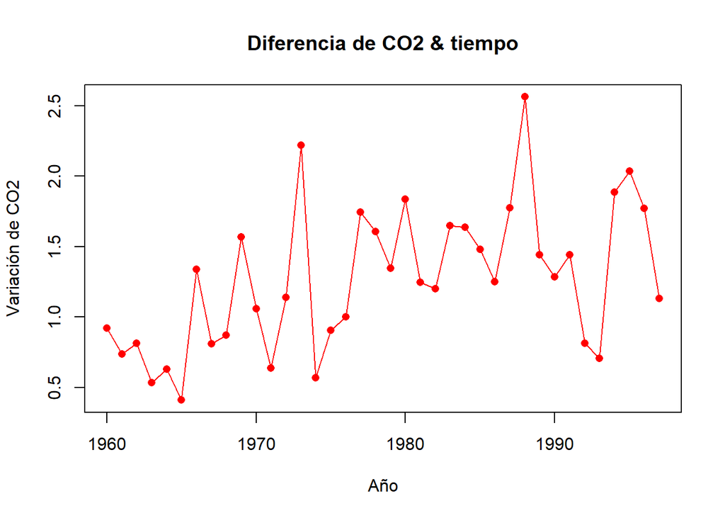

```r
plot(x = df_co2$year[2:39], y = vect_diferencia, xlab = "Año", ylab = "Variación de CO2",
    main = "Diferencia de CO2 & tiempo", type = "o", pch = 16, col="red")
```

- La diferencia de concentración de CO<sub>2</sub> entre 2020 y 2019 fue igual a 2.64. Agregar un punto rojo representando esa diferencia al plot ya creado (usar una forma diferentes como **pch = 4**)

Solución:

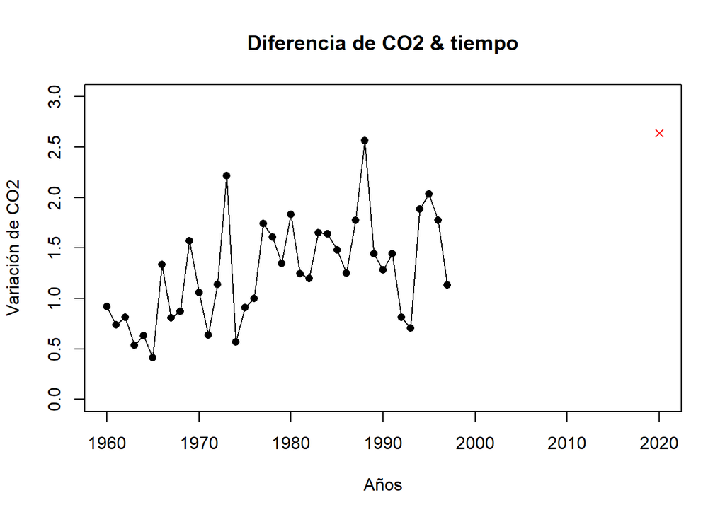

```r
plot(x = df_co2$year[2:39], y = vect_diferencia, xlab = "Años", ylab = "Variación de CO2",
    main = "Diferencia de CO2 & tiempo", type = "o", pch = 16, xlim = c(1960,2020),
    ylim = c(0,3))
points(2020, 2.64, pch = 4, col = "red")
```

14. Piden:
- Leer el archivo **rainfall.csv** como un **data.frame**
- Calcula e imprime un vector con los nombres de las estaciones donde al menos uno de los meses tiene una precipitación superior a 180mm.

Solución:

```r
df_rain <- as_tibble(read_csv("ProgramacionR-master/data/rainfall.csv"))
names_est <- dplyr::select(df_rain, sep:apr, name) %>%
 dplyr::filter(sep > 180 | oct > 180 | nov > 180 | dec > 180 |
                 jan > 180 | feb > 180 |mar >180) %>%
 dplyr::select(name)
names_est <- as.vector(names_est$name)
names_est
```

```
## [1] "Golan Farm" "Eilon"      "Fasutta"    "Yehiam"     "Kfar Mahol"
## [6] "Meron"      "Horashim"
```